# 自作データの可視化

店舗数の例

[岩田真一郎](https://shinichiro-iwata.github.io/)（ [神奈川大学経済学部](https://www.econ.kanagawa-u.ac.jp/)）

2022-06-04作成，2024-03-03改訂

# 1 目的

`NipponMap`に他のウェブサイトの情報から作成した都道府県別データを加え，可視化．今回はユニクロとサッカーショップKAMOの店舗数を表現する．

ライブラリ：`sf`，`tidyverse`，`Nipponmap`

```r
library(sf)
library(tidyverse)
library(NipponMap)
```

# 2 店舗数データの作成

**シェープファイル**

- これまでの例（[1](https://shinichiro-iwata.github.io/GIS-data-visualization/prefecuture-level-data-visualization.html)，[1.1](https://shinichiro-iwata.github.io/GIS-data-visualization/pld1-visualization.html)を参照）のように`NipponMap`を読込．

```r
Nippon_map<-read_sf("shapes/jpn.shp",
                     crs="WGS84")
```

**ユニクロとサッカーショップKAMOの店舗数データの作成**

- [ユニクロ](https://map.uniqlo.com/jp/ja/)（アクセス日：2022-04-15）と[サッカーショップKAMO](https://www.sskamo.co.jp)（アクセス日：2022-04-15）のウェブサイトから都道府県別の舗数を調べ，都道府県の順番に気をつけながらデータ（拡張子を`.csv`とする）を**「自分で」**作成する．Excelで保存する場合は，CSV（コンマ区切り）（*.csv）を選択． ここでは，`stores.csv`と名付ける．
  - `stores.csv`を作業ファイルに保存．
  - `read.csv`：CSVファイルの読込．`Stores`と名付ける．

```r
#csvファイルの読込
Stores<-read.csv("stores.csv")

#上から6行のデータの中身
Stores %>%
  head()
```

|  | SP_ID | uniqulo | kamo |
| --- | --- | --- | --- |
| 1 | 1 | 29 | 1 |
| 2 | 2 | 8 | 0 |
| 3 | 3 | 8 | 0 |
| 4 | 4 | 14 | 1 |
| 5 | 5 | 6 | 0 |
| 6 | 6 | 8 | 0 |

**データの加工及び結合**

- `Nippon_map`の`SP_ID`は`<chr>`（character：文字列），`Stores`の`SP_ID`は`<int>`（integer：数値）のため結合できない．
  - そこで，`Stores`の``SP_ID`を文字列に変換．データ名は`Stores`のまま．
- 地図データ（`Nippon_map`）と店舗数データ（`Stores`）を`SP_ID`で結合（`left_join`）し，`Stores_map`と名付ける．

```r
#データ結合のため文字列に変更
Stores %>%
  mutate(SP_ID=as.character(SP_ID)) ->
  Stores

#地図データと店舗数データの結合
Stores_map<-
  left_join(Nippon_map, Stores,
            by=c("SP_ID"))
```

# 3 店舗数の可視化

**ユニクロ店舗数の完成図**

- 今回は色分けに[`viridis`](https://cran.r-project.org/web/packages/viridis/vignettes/intro-to-viridis.html)を利用．[^1]
  - `option="G"`は`option="mako"`に等しい．
- `labs()`内に出典を表記（`caption`）．

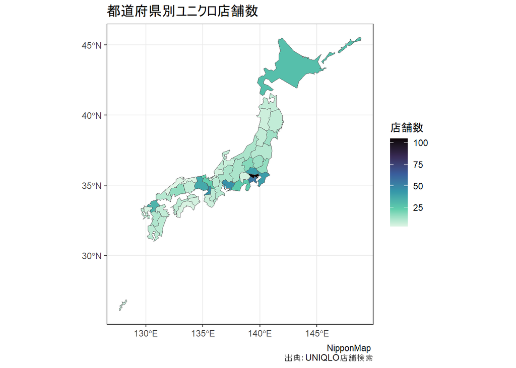

```r
ggplot()+
  geom_sf(data=Stores_map,
          aes(fill=uniqulo))+
  scale_fill_viridis_c(option="G", direction=-1)+
  labs(fill="店舗数",
       caption="NipponMap
       出典：UNIQLO店舗検索")+
  ggtitle("都道府県別ユニクロ店舗数")+
  theme_bw()
```

**サッカーショップKAMO店舗数の完成図**

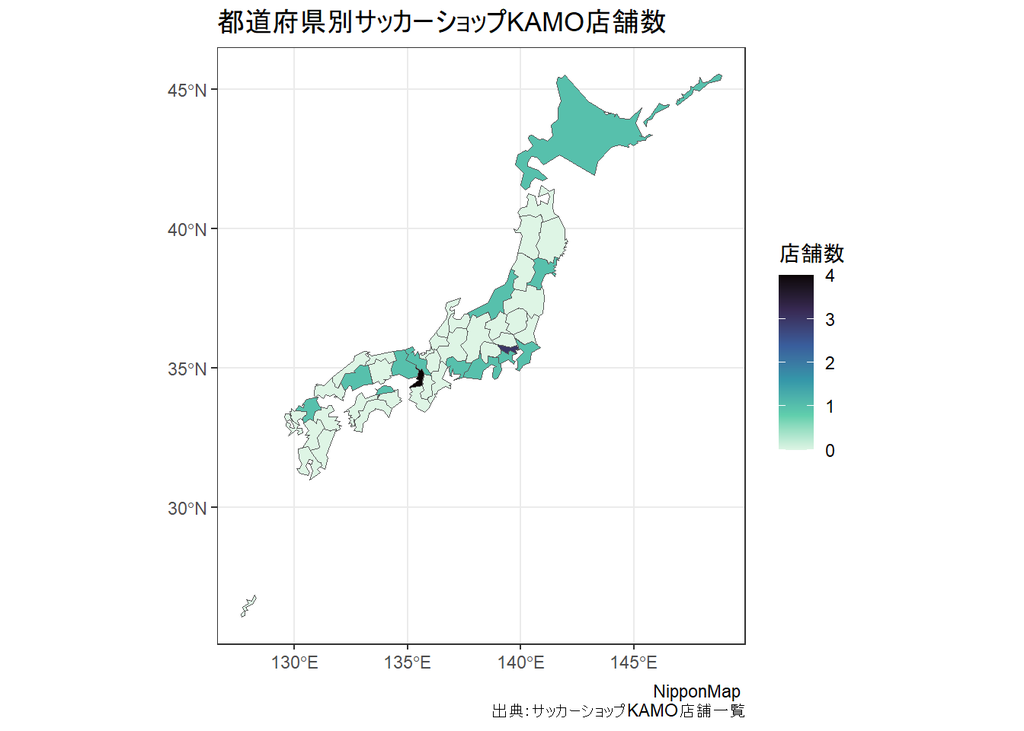

```r
ggplot()+
  geom_sf(data=Stores_map,
          aes(fill=kamo))+
  scale_fill_viridis_c(option="G", direction=-1)+
  labs(fill="店舗数",
       caption="NipponMap
       出典：サッカーショップKAMO店舗一覧")+
  ggtitle("都道府県別サッカーショップKAMO店舗数")+
  theme_bw()
```

# 4 応用

## 4.1 色のマニュアル指定

サッカーショップは扱っている商品に偏り（サッカー商品のみ）があるため，人口の多い都道府県のみに立地する傾向．多くの都道府県において店舗がゼロ．

- そこで，店舗数ゼロの都道府県を白色で埋める．
  - その他の階級の色もマニュアル指定．
- これまで使用してきた`mako`を利用するため，カラーコードを調べる．

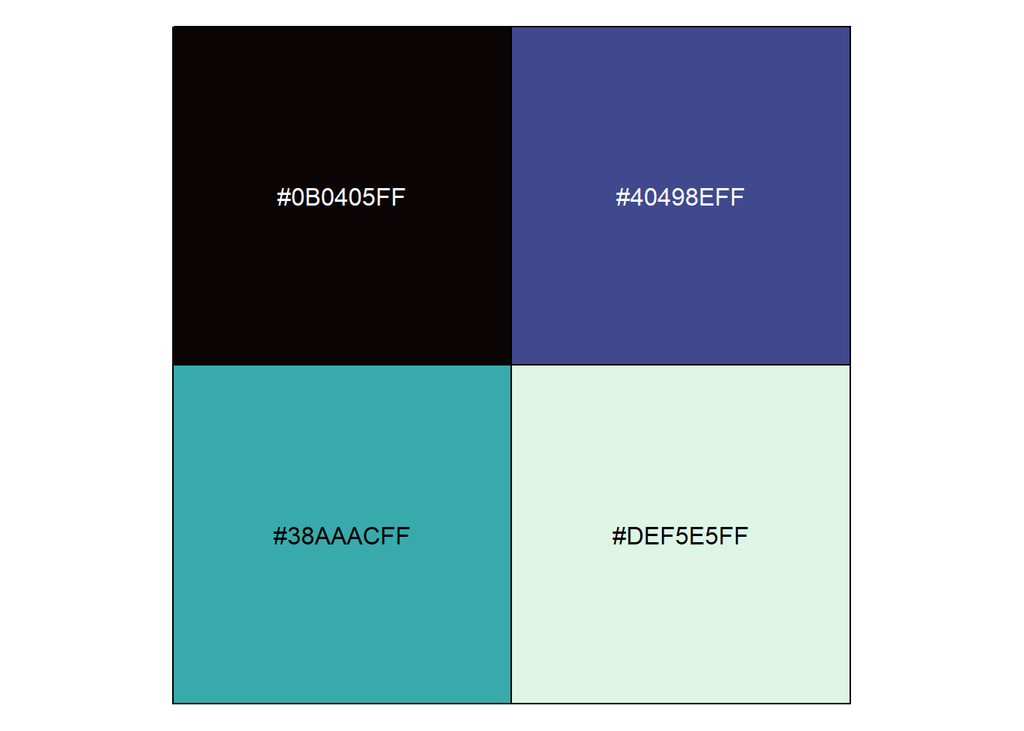

```r
#カラーコードを調べるため．
library(scales)

#カラーコードの表示（4色）．
show_col(viridis_pal(option="G")(4))
```

**完成図**

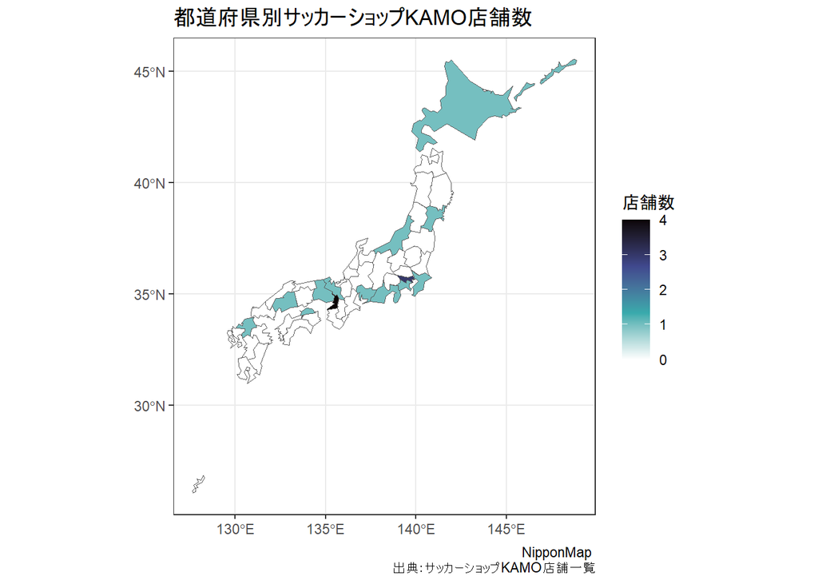

```r
#色のマニュアル指定
my_colors<-
  c("white", "#38AAACFF", "#40498EFF", "#0B0405FF")

ggplot()+
  geom_sf(data=Stores_map,
          aes(fill=kamo)) +
  scale_fill_gradientn(colors=my_colors)+
  labs(fill="店舗数",
       caption="NipponMap
       出典：サッカーショップKAMO店舗一覧")+
  ggtitle("都道府県別サッカーショップKAMO店舗数")+
  theme_bw()
```

**Rによる地理空間データの可視化**

- チュートリアル[ホーム](https://shinichiro-iwata.github.io/geospatial-data-visualization/)
[^1]: 必要に応じてパッケージをダウンロード（`install.packages("viridis")`し，`library(viridis)`で呼び出す．